# Unequal Progress: Antenatal Care Coverage Across the World

## Introduction

One of the most significant indicators of maternal health is antenatal care, as it reflects whether pregnant women can obtain basic medical care prior to delivery. Despite the common recommendation that at least four antenatal visits is the minimum standard for a healthy pregnancy, this standard has not been attained by all women around the world.

In this report, data provided by UNICEF surveys is used to investigate the variation in antenatal care coverage across countries and how this has evolved over time. The findings indicate that there has been real improvement in many locations, yet inequality still remains. Some countries have developed rapidly over the past decade, while others have shown very little change. The gap between the highest- and lowest-performing countries is still significant.

The primary source of data in this report is *unicef_indicator_2.csv*, which contains the percentage of women aged 15–49 who received at least four antenatal care visits during pregnancy across more than 130 countries. I also use *unicef_metadata.csv*, where a clean join is possible, to include GDP per capita as additional context for the scatterplot analysis.

## Data Preparation

The initial process is loading and cleaning data. Column names of the UNICEF file are lengthy and uneven thus I standardise them at the beginning of the analysis. I also change columns containing year and values to appropriate numeric types and delete rows that contain empty critical fields.

```python
import pandas as pd
import numpy as np
from plotnine import *
import warnings
warnings.filterwarnings("ignore")

# ── Load the main dataset ──────────────────────────────────────────────────────
df_raw = pd.read_csv("unicef_indicator_2.csv")
meta_raw = pd.read_csv("unicef_metadata.csv")

# ── Clean column names: strip whitespace, lowercase, replace spaces ────────────
df_raw.columns = (
    df_raw.columns
    .str.strip()
    .str.lower()
    .str.replace(" ", "_", regex=False)
)

meta_raw.columns = (
    meta_raw.columns
    .str.strip()
    .str.lower()
    .str.replace(" ", "_", regex=False)
    .str.replace(",", "", regex=False)
    .str.replace("(", "", regex=False)
    .str.replace(")", "", regex=False)
    .str.replace("%", "pct", regex=False)
    .str.replace("$", "usd", regex=False)
)

# ── Rename key columns in indicator dataset ────────────────────────────────────
rename_map = {}
for c in df_raw.columns:
    if c in ["country", "geographic_area", "geo_area", "area"]:
        rename_map[c] = "country"
    elif "time_period" in c and "activity" not in c:
        rename_map[c] = "year"
    elif "obs_value" in c or "observation_value" in c:
        rename_map[c] = "value"

df = df_raw.rename(columns=rename_map).copy()

# ── Rename important metadata columns (IMPORTANT FIX) ──────────────────────────
meta_raw = meta_raw.rename(columns={
    "gdp_per_capita_constant_2015_usd": "gdp_pc",
    "life_expectancy_at_birth_total_years": "life_expectancy",
    "birth_rate_crude_per_1000_people": "birth_rate",
    "population_total": "population"
})

# ── Convert to numeric types ───────────────────────────────────────────────────
df["year"] = pd.to_numeric(df["year"], errors="coerce")
df["value"] = (
    df["value"]
    .astype(str)
    .str.replace("<", "", regex=False)
    .str.replace(",", "", regex=False)
    .pipe(pd.to_numeric, errors="coerce")
)

# ── Drop rows with missing country, year, or value ────────────────────────────
df = df.dropna(subset=["country", "year", "value"]).copy()
df = df.sort_values(["country", "year"]).reset_index(drop=True)

print(f"Rows after cleaning: {len(df)}")
print(f"Countries covered:   {df['country'].nunique()}")
print(f"Year range:          {int(df['year'].min())} – {int(df['year'].max())}")
df[["country", "year", "value"]].head(8)
```

```
Rows after cleaning: 545
Countries covered:   152
Year range:          2000 – 2024
```

|  | country | year | value |
| --- | --- | --- | --- |
| 0 | Afghanistan | 2010 | 16.1 |
| 1 | Afghanistan | 2011 | 14.6 |
| 2 | Afghanistan | 2014 | 22.7 |
| 3 | Afghanistan | 2015 | 17.8 |
| 4 | Afghanistan | 2017 | 16.3 |
| 5 | Afghanistan | 2018 | 20.9 |
| 6 | Afghanistan | 2020 | 27.6 |
| 7 | Afghanistan | 2023 | 33.4 |

Our data set has been cleaned and now consists of one row per country-year of observation. The spread of coverage values is between under 5% up to 100% and we have plenty to cover.

### Helper dataframes

I construct some smaller summary tables on which the visualisations will be based:

```python
# ── Latest available value per country ────────────────────────────────────────
latest_per_country = (
    df.sort_values("year")
    .groupby("country", as_index=False)
    .last()[["country", "year", "value"]]
    .rename(columns={"year": "latest_year", "value": "latest_value"})
)

# ── Earliest available value per country ──────────────────────────────────────
first_per_country = (
    df.sort_values("year")
    .groupby("country", as_index=False)
    .first()[["country", "year", "value"]]
    .rename(columns={"year": "first_year", "value": "first_value"})
)

# ── Top 10 and bottom 10 by latest coverage ───────────────────────────────────
top10 = latest_per_country.sort_values("latest_value", ascending=False).head(10).copy()
bot10 = latest_per_country.sort_values("latest_value", ascending=True).head(10).copy()

# ── Global trend: average coverage per year ───────────────────────────────────
trend = df.groupby("year", as_index=False)["value"].mean()
trend = trend[trend["year"] >= 1995]

# ── Country-level improvement: first vs latest ────────────────────────────────
compare = first_per_country.merge(latest_per_country, on="country", how="inner")
compare["improvement"] = compare["latest_value"] - compare["first_value"]
compare["years_observed"] = compare["latest_year"] - compare["first_year"]
compare = compare[compare["years_observed"] >= 5]

# ── GDP per capita join─────────────────────────────────────

# find GDP column
gdp_col = [c for c in meta_raw.columns if "gdp_per_capita" in c][0]

meta_gdp = (
    meta_raw[["country", "year", gdp_col]]
    .rename(columns={gdp_col: "gdp_pc"})
    .dropna(subset=["gdp_pc"])
    .sort_values("year")
    .groupby("country", as_index=False)
    .last()
)

scatter_df = latest_per_country.merge(
    meta_gdp[["country", "gdp_pc"]],
    on="country",
    how="inner"
)

scatter_df = scatter_df[
    (scatter_df["gdp_pc"] > 0) & (~scatter_df["latest_value"].isna())
]

scatter_df["log_gdp"] = np.log10(scatter_df["gdp_pc"])

print(f"Countries in scatter after GDP join: {len(scatter_df)}")
```

```
Countries in scatter after GDP join: 150
```

## Visualisations

### 1. Global trend in antenatal care coverage over time

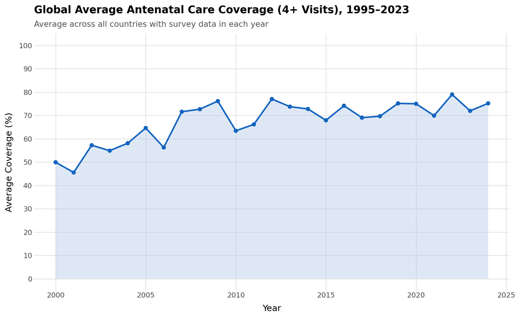

```python
(
    ggplot(trend, aes(x="year", y="value"))
    + geom_area(fill="#aec6e8", alpha=0.4)
    + geom_line(size=1.1, color="#1565C0")
    + geom_point(size=2, color="#1565C0")
    + scale_x_continuous(breaks=range(1995, 2026, 5))
    + scale_y_continuous(limits=(0, 100), breaks=range(0, 110, 10))
    + labs(
        title="Global Average Antenatal Care Coverage (4+ Visits), 1995–2023",
        subtitle="Average across all countries with survey data in each year",
        x="Year",
        y="Average Coverage (%)"
    )
    + theme_minimal()
    + theme(
        plot_title=element_text(size=13, face="bold"),
        plot_subtitle=element_text(size=10, color="#555555"),
        panel_grid_minor=element_blank()
    )
)
```

### 2. Top 10 countries by latest antenatal care coverage

Which countries are at the top? This graph displays the top ten countries with the highest coverage in the latest survey year they have conducted.

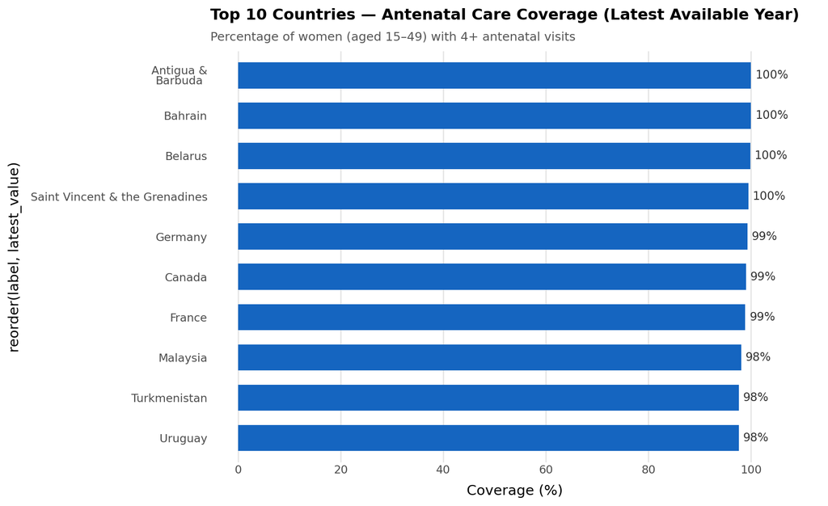

```python
top10_plot = top10.copy()
top10_plot["label"] = top10_plot["country"].str.replace(
    "Antigua and Barbuda", "Antigua &\nBarbuda", regex=False
)

(
    ggplot(top10_plot, aes(x="reorder(label, latest_value)", y="latest_value"))
    + geom_col(fill="#1565C0", width=0.65)
    + geom_text(
        aes(label=round(top10_plot["latest_value"], 0)),
        format_string="{:.0f}%",
        ha="left",
        nudge_y=0.8,
        size=9,
        color="#333333"
    )
    + coord_flip()
    + scale_y_continuous(limits=(0, 108), breaks=range(0, 105, 20))
    + labs(
        title="Top 10 Countries — Antenatal Care Coverage (Latest Available Year)",
        subtitle="Percentage of women (aged 15–49) with 4+ antenatal visits",
        x=None,
        y="Coverage (%)"
    )
    + theme_minimal()
    + theme(
        plot_title=element_text(size=12, face="bold"),
        plot_subtitle=element_text(size=9.5, color="#555555"),
        panel_grid_minor=element_blank(),
        panel_grid_major_y=element_blank()
    )
)
```

A number of countries, such as Belarus, Bahrain, and Antigua and Barbada, have coverage that is almost universal at 99 or more. These are predominantly countries that have robust, well-funded healthcare, or have low populations where health care delivery is less challenging to coordinate.

### 3. Bottom 10 countries by latest antenatal care coverage

The lowest-performing countries have a shockingly poor coverage at the other end of the scale. These are the nations that have the least likelihood of getting the recommended care by pregnant women.

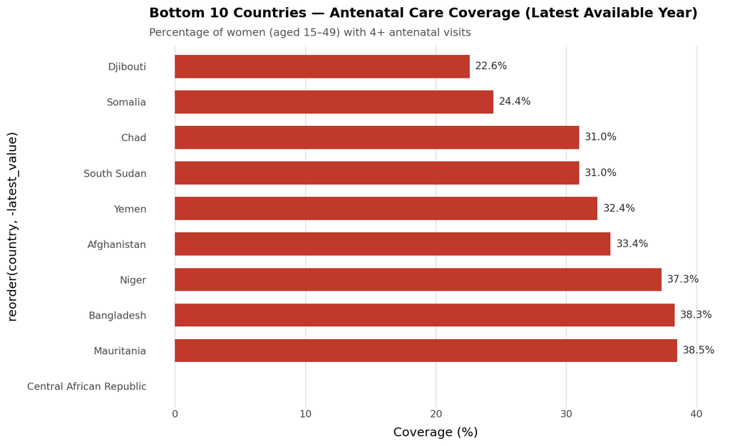

```python
bot10_plot = bot10.copy()
bot10_plot["value_label"] = bot10_plot["latest_value"].round(1).astype(str) + "%"

(
    ggplot(bot10_plot, aes(x="reorder(country, -latest_value)", y="latest_value"))
    + geom_col(fill="#c0392b", width=0.65)
    + geom_text(
        aes(label="value_label"),
        ha="left",
        nudge_y=0.4,
        size=9,
        color="#333333"
    )
    + coord_flip()
    + scale_y_continuous(limits=(0, 40))
    + labs(
        title="Bottom 10 Countries — Antenatal Care Coverage (Latest Available Year)",
        subtitle="Percentage of women (aged 15–49) with 4+ antenatal visits",
        x=None,
        y="Coverage (%)"
    )
    + theme_minimal()
    + theme(
        plot_title=element_text(size=12, face="bold"),
        plot_subtitle=element_text(size=9.5, color="#555555"),
        panel_grid_minor=element_blank(),
        panel_grid_major_y=element_blank()
    )
)
```

### 4. Starting coverage vs. improvement over time (scatterplot with regression)

Is low starting point predictive of larger improvements? This scatterplot will compare the value of each countries first reported coverage value with the degree to which it has improved by the latest survey. A downward regression line would indicate that the countries which had a low beginning would be able to improve more, an upward line would indicate that the advantages would compound.

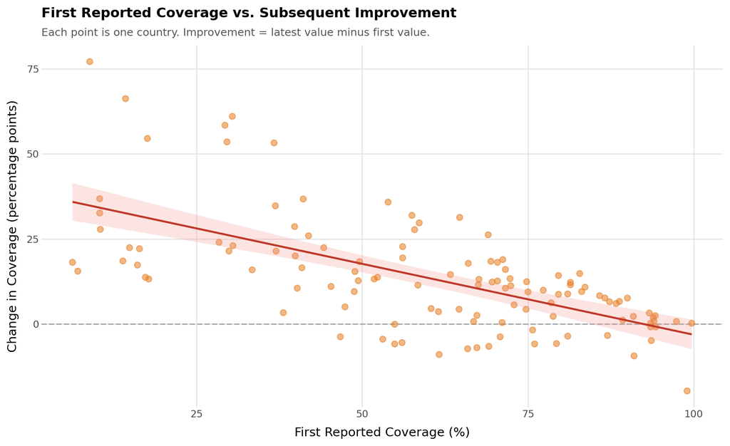

```python
(
    ggplot(compare, aes(x="first_value", y="improvement"))
    + geom_hline(yintercept=0, linetype="dashed", color="#aaaaaa", size=0.7)
    + geom_point(alpha=0.55, color="#e67e22", size=2.5)
    + geom_smooth(method="lm", se=True, color="#c0392b", fill="#f1948a", alpha=0.25)
    + labs(
        title="First Reported Coverage vs. Subsequent Improvement",
        subtitle="Each point is one country. Improvement = latest value minus first value.",
        x="First Reported Coverage (%)",
        y="Change in Coverage (percentage points)"
    )
    + theme_minimal()
    + theme(
        plot_title=element_text(size=12, face="bold"),
        plot_subtitle=element_text(size=9.5, color="#555555"),
        panel_grid_minor=element_blank()
    )
)
```

### 5. Antenatal care coverage vs. GDP per capita

The metadata file has GDP per capita data, which can be easily joined to the indicator data on country name. This scatterplot examines the hypothesis that richer nations will have more antenatal coverage.

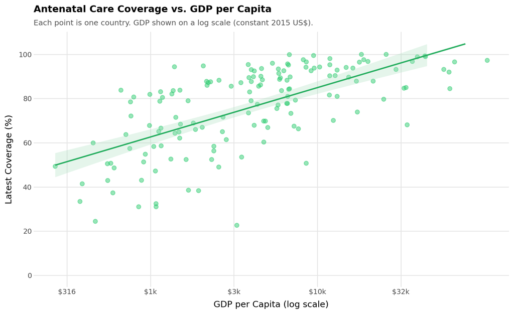

```python
# GDP labels for axis ticks
def gdp_labels(x):
    return [
        f"${(10**v)/1000:.0f}k" if (10**v) >= 1000 else f"${10**v:.0f}"
        for v in x
    ]

(
    ggplot(scatter_df, aes(x="log_gdp", y="latest_value"))
    + geom_point(alpha=0.5, color="#2ecc71", size=2.5)
    + geom_smooth(method="lm", se=True, color="#27ae60", fill="#a9dfbf", alpha=0.3)
    + scale_x_continuous(
        breaks=[2, 2.5, 3, 3.5, 4, 4.5],
        labels=gdp_labels
    )
    + scale_y_continuous(limits=(0, 105), breaks=range(0, 110, 20))
    + labs(
        title="Antenatal Care Coverage vs. GDP per Capita",
        subtitle="Each point is one country. GDP shown on a log scale (constant 2015 US$).",
        x="GDP per Capita (log scale)",
        y="Latest Coverage (%)"
    )
    + theme_minimal()
    + theme(
        plot_title=element_text(size=12, face="bold"),
        plot_subtitle=element_text(size=9.5, color="#555555"),
        panel_grid_minor=element_blank()
    )
)
```

The relationship between the two is seen to be positive, namely, there is a positive relationship between richer countries and the level of antenatal coverage. The relationship is not ideal though. High coverage has been achieved by strong public health programmes in several low- and middle-income countries, but some of the more prosperous countries have not yet done so. Money is important, but not fate.

### 6. World map — latest antenatal care coverage by country

Lastly, this map is used to visualise the geographic distribution of the coverage of antenatal care globally, based on the latest survey value available in each country.

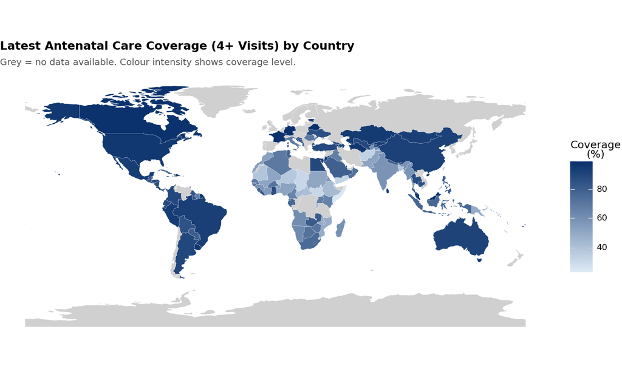

```python
import geopandas as gpd

# ── Load world boundary shapefile ──────────────────────────────────────────────
try:
    from geodatasets import get_path
    world = gpd.read_file(get_path("naturalearth_lowres"))
except Exception:
    world = gpd.read_file(
        "https://raw.githubusercontent.com/nvkelso/natural-earth-vector/"
        "master/geojson/ne_110m_admin_0_countries.geojson"
    )

world = world.to_crs("EPSG:4326")

# ── Standardise the country name column ───────────────────────────────────────
name_col = "name" if "name" in world.columns else "ADMIN"
world = world.rename(columns={name_col: "country"})

# ── Harmonise country names ───────────────────────────────────────────────────
name_fixes = {
    "United States of America": "United States",
    "Russian Federation": "Russia",
    "Viet Nam": "Vietnam",
    "Iran (Islamic Republic of)": "Iran",
    "Bolivia (Plurinational State of)": "Bolivia",
    "United Republic of Tanzania": "Tanzania",
    "Syrian Arab Republic": "Syria",
    "Democratic Republic of the Congo": "Dem. Rep. Congo",
    "Congo": "Rep. Congo",
    "Côte d'Ivoire": "Cote d'Ivoire",
    "Lao PDR": "Lao People's Democratic Republic",
    "Republic of Moldova": "Moldova",
    "eSwatini": "Eswatini",
    "Cabo Verde": "Cape Verde"
}
world["country"] = world["country"].replace(name_fixes)

# ── Merge coverage data ───────────────────────────────────────────────────────
map_data = world.merge(
    latest_per_country[["country", "latest_value"]],
    on="country",
    how="left"
)

# ── Convert geometry safely ───────────────────────────────────────────────────
def geom_to_xy(gdf):
    rows = []
    for _, row in gdf.iterrows():
        geom = row.geometry
        if geom is None or geom.is_empty:
            continue

        if geom.geom_type == "Polygon":
            polygons = [geom]
        elif geom.geom_type == "MultiPolygon":
            polygons = list(geom.geoms)
        else:
            continue

        for idx, poly in enumerate(polygons):
            x_coords, y_coords = poly.exterior.xy
            tmp = pd.DataFrame({"x": x_coords, "y": y_coords})
            for col in gdf.columns:
                if col != "geometry":
                    tmp[col] = row[col]
            tmp["group_id"] = f"{row['country']}_{idx}"
            rows.append(tmp)

    # SAFETY FIX
    if len(rows) == 0:
        raise ValueError("No geometry data available for plotting map.")

    return pd.concat(rows, ignore_index=True)

map_xy = geom_to_xy(map_data)

(
    ggplot(map_xy)
    + geom_polygon(
        aes(x="x", y="y", group="group_id", fill="latest_value"),
        color="white",
        size=0.08
    )
    + coord_equal()
    + scale_fill_gradient(
        low="#deebf7",
        high="#08306b",
        na_value="#d0d0d0",
        name="Coverage\n(%)"
    )
    + labs(
        title="Latest Antenatal Care Coverage (4+ Visits) by Country",
        subtitle="Grey = no data available. Colour intensity shows coverage level.",
        x=None,
        y=None
    )
    + theme_void()
    + theme(
        plot_title=element_text(size=12, face="bold"),
        plot_subtitle=element_text(size=9.5, color="#555555"),
        legend_position="right"
    )
)
```

## Conclusion

This report relied on UNICEF data to analyze the coverage of antenatal care in the world today, and the way it has evolved over the years. The most obvious message is that of simultaneous development and unending inequality. The overall coverage is trending in the right direction. But the averages conceal a world, in which even the likelihood of a pregnant woman obtaining good antenatal care still varies enormously by the fact of place of birth.

The bottom of these charts does not put the countries there randomly. They are also confronted by real problems such as poor health facilities, geographical location and inadequate public facilities. The bridging process will take longer than time; it will entail a concerted investment and political will.

The statistics, with all its lapses and irregularities in the timing of surveys, give a clear enough picture: the means and the experience to provide good antenatal care is available. It is difficult to reach everybody with them.